# STOR 455 Exam #1

## Name: Surya Poddutoori

### Directions:

When you complete the exam:

1. Save the notebook (and create an html file)
2. View the html file of your exam in a web browser to verfiy all is there
3. Upload your html file to Sakai under Assignments/Exam #1

### Question 1

The Game_Data dataset contains a list of video games with sales greater than 100,000 copies. It was generated by scrapes of vgchartz.com and Metacritic. The variables included are:

| Variables | Descriptions |
| --- | --- |
| name | The game’s name |
| platform | Platform of the games release (i.e. PC,PS4, etc.) |
| global_sales | Total worldwide sales in millions of dollars |
| critic_score | Aggregate score compiled by Metacritic staff |
| critic_count | The number of critics who gave the critic_score |
| user_score | Score by Metacritic’s subscribers |
| user_count | Number of users who gave the user_score |

Game_Data contains many blank values. A cleaned version of this data set, which omits the cases containing blank values is created in the R chunk below. You should use the Game_Data_Cleaner data set for this problem!!!

**Run the R chunk below after importing the Game_Data datset**

```r
library(readr)
Game_Data <- read_csv("C:/Users/samee/Google Drive/College/STOR 455/R/Datasets/Game_Data.csv")
Game_Data_Cleaner = na.omit(Game_Data)
head(Game_Data_Cleaner)
```

| name | platform | global_sales | critic_score | critic_count | user_score | user_count |
| --- | --- | --- | --- | --- | --- | --- |
| [Prototype] | X360 | 1.27 | 78 | 83 | 7.9 | 327 |
| [Prototype] | PS3 | 1.19 | 79 | 53 | 7.8 | 271 |
| 2010 FIFA World Cup South Africa | PS3 | 1.16 | 82 | 56 | 7.8 | 43 |
| 2010 FIFA World Cup South Africa | X360 | 0.82 | 83 | 61 | 8.2 | 49 |
| 2010 FIFA World Cup South Africa | PSP | 0.42 | 69 | 11 | 8.8 | 6 |
| 2010 FIFA World Cup South Africa | Wii | 0.40 | 70 | 19 | 6.3 | 9 |

#### Part A

Construct a simple linear regression model using critic_score to predict global_sales. Plot the data and the regression line on the same axes. You do **not** need to comment on the effectiveness of the model or examine the residuals.

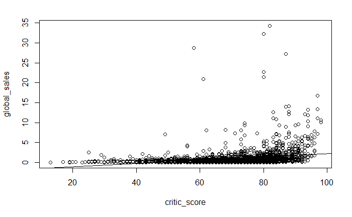

```r
plot(global_sales ~ critic_score, data=Game_Data_Cleaner)
mod1 = lm(global_sales ~ critic_score, data=Game_Data_Cleaner)
abline(mod1)
```

#### Part B

Perform a hypothesis test to test the strength of the linear relationship between the variables using **one** of the three methods. Cite your hypotheses, p-value, and conclusions.

```r
summary(mod1)
```

```
Call:
lm(formula = global_sales ~ critic_score, data = Game_Data_Cleaner)

Residuals:
   Min     1Q Median     3Q    Max
-1.712 -0.731 -0.351  0.168 32.921

Coefficients:
              Estimate Std. Error t value Pr(>|t|)
(Intercept)  -1.896520   0.181156  -10.47   <2e-16 ***
critic_score  0.040311   0.002571   15.68   <2e-16 ***
---
Signif. codes:  0 ‘***’ 0.001 ‘**’ 0.01 ‘*’ 0.05 ‘.’ 0.1 ‘ ’ 1

Residual standard error: 1.896 on 2666 degrees of freedom
Multiple R-squared:  0.08444,   Adjusted R-squared:  0.0841
F-statistic: 245.9 on 1 and 2666 DF,  p-value: < 2.2e-16
```

Consider the hypothesis test for slope. The Null hypothesis states that the slope of the model is equal to 0, it assumes that there is no correlation. The alternate hypothesis states that the slope of the model is not equal to 0, it assumes that there is a correlation. My hypothesis is that a linear relation exists.

The p-value for this hypothesis test is 2e-16, which is essentially 0. Thus proving at an alpha level of 99.9 percent we can reject the null hypothesis in favor of the alternate one. The t-value is also extremely large at 15.68, which explains the extremely low p-value. ***

#### Part C

Use your model to construct an interval to predict (at the 95% level) the global sales of all games with a mean critic_score of 75 (You will need to create a new dataframe).

```r
newx = data.frame(critic_score=75)
predict.lm(mod1, newx, level = .95, interval = "confidence")
```

```
       fit      lwr      upr
1 1.126824 1.048764 1.204885
```

```r
predict.lm(mod1, newx, level = .95, interval = "prediction")
```

```
       fit       lwr      upr
1 1.126824 -2.591823 4.845471
```

#### Part D

Construct a multiple linear regression model using any/all of the quantitave variables (do not use the variables name or platform) to predict global_sales. Briefly discuss below why the model that you constructed is the most effective model. You do **not** need to analyze the residuals.

```r
all=regsubsets(global_sales ~ critic_score + critic_count + user_score + user_count, data=Game_Data_Cleaner,nbest=2)
ShowSubsets(all)
```

|  | critic_score | critic_count | user_score | user_count | Rsq | adjRsq | Cp |
| --- | --- | --- | --- | --- | --- | --- | --- |
| 1 ( 1 ) |  |  |  | * | 23.60 | 23.57 | 108.31 |
| 1 ( 2 ) |  | * |  |  | 10.91 | 10.88 | 568.56 |
| 2 ( 1 ) | * |  |  | * | 25.69 | 25.63 | 34.48 |
| 2 ( 2 ) |  | * |  | * | 25.56 | 25.50 | 39.12 |
| 3 ( 1 ) | * | * |  | * | 26.50 | 26.42 | 6.94 |
| 3 ( 2 ) | * |  | * | * | 25.76 | 25.67 | 33.92 |
| 4 ( 1 ) | * | * | * | * | 26.61 | 26.50 | 5.00 |

```r
mod2 = lm(global_sales ~ critic_score + critic_count + user_score + user_count, data=Game_Data_Cleaner)
summary(mod2)
```

```
Call:
lm(formula = global_sales ~ critic_score + critic_count + user_score +
    user_count, data = Game_Data_Cleaner)

Residuals:
   Min     1Q Median     3Q    Max
-8.067 -0.495 -0.226  0.120 32.106

Coefficients:
               Estimate Std. Error t value Pr(>|t|)
(Intercept)  -0.6598628  0.1816608  -3.632 0.000286 ***
critic_score  0.0191119  0.0032230   5.930 3.42e-09 ***
critic_count  0.0103400  0.0018596   5.560 2.96e-08 ***
user_score   -0.0571357  0.0287982  -1.984 0.047358 *
user_count    0.0020482  0.0000965  21.225  < 2e-16 ***
---
Signif. codes:  0 ‘***’ 0.001 ‘**’ 0.01 ‘*’ 0.05 ‘.’ 0.1 ‘ ’ 1

Residual standard error: 1.698 on 2663 degrees of freedom
Multiple R-squared:  0.2661,    Adjusted R-squared:  0.265
F-statistic: 241.4 on 4 and 2663 DF,  p-value: < 2.2e-16
```

The model I’ve constructed with the 4 predictors (critic_score, critic_count, user_score, user_count), is the best one because of its very low Cp and highest r squared (of the listed ones). It represents the best set of predictors for global_sales. ***

#### Part E

Calculate the variance inflation factor for your model from part D in the R chunk below. In the text below the chunk, very briefly explain what the values of the variance inflation factor say about your model.

```r
vif(mod2)
```

```
critic_score critic_count   user_score   user_count
    1.958678     1.443826     1.636333     1.280199
```

The VIF suggests that there doesn’t appear to be a strong level of multicollinearity in the model. Although the p-values are close to 0 and are all significant at an alpha value of .95, the model doesn’t seem to be multicollinear. Which makes sense because the adjusted r^2 is low at .2650 (26.50). Not a strong case of multicollinearity. ***

### Question 2

Climatologists have been measuring the amount of sea ice in both the Arctic and Antarctic regions for a number of years. This SeaIce data gives information about the amount of sea in the arctic region as measured in September (the time when the amount of ice is at its least) since 1979. The basic research question is to see if we can use time to model the amount of sea ice.

In fact, there are two ways to measure the amount of sea ice: Area and Extent. Area measures the actual amount of space taken up by ice. Extent measures the area inside the outer boundaries created by the ice. If there are areas inside the outer boundaries that are not ice (think about a slice of swiss cheese), then the Extent will be a larger number than the Area. In fact, this is almost always true.

**Run the R chunk below after importing the SeaIce dataset.**

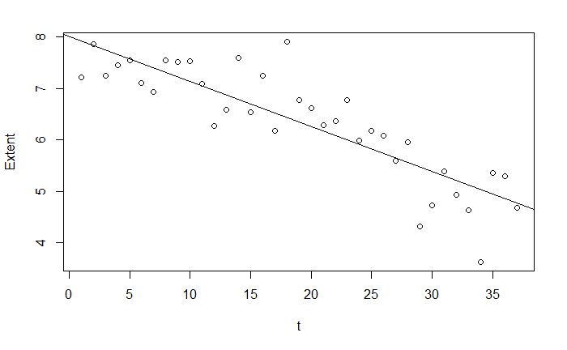

```r
library(readr)
SeaIce <- read_csv("C:/Users/samee/Google Drive/College/STOR 455/R/Datasets/SeaIce.csv")
plot(Extent~t, data = SeaIce)
IceModel=lm(Extent~t, data = SeaIce)
abline(IceModel)
```

```r
plot(IceModel$residuals~IceModel$fitted.values)
abline(0,0)
```

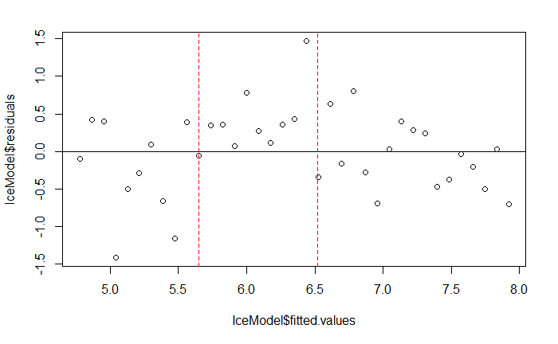

```r
abline(v=c(5.65,6.52), col=c("red", "red"), lty=c(2,2), lwd=c(1, 1)) #Draws red dashed vertical lines
```

In the plot of Extent versus t (time), a linear model appears to be a useful fit to describe the relationship between the variables. Upon further inspection of the residuals vs fitted values, you can see that for values in the middle range of fitted values (between the red lines), there are no negative residuals. This denotes that there may be a curve to the trend in data.

Apply a transformation to the data, and make a new linear model with this transformed data that is a better fit for the data (and no longer has the above issue in the residuals)

**Possible tranformations include taking the log of one or both variables, or raising one variable to a power (a^b).**

Include a plot of the transformed data with your new linear model and a plot of the residuals vs fitted values. You do not need to plot the original data with the curved, nonlinear model. Briefly explain why this transformation provides a better fit for a linear model.

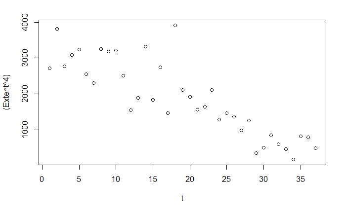

```r
plot((Extent^4)~(t^4), data=SeaIce)
mod3 = lm((Extent^4)~(t^4), data=SeaIce)
abline(0,0)
```

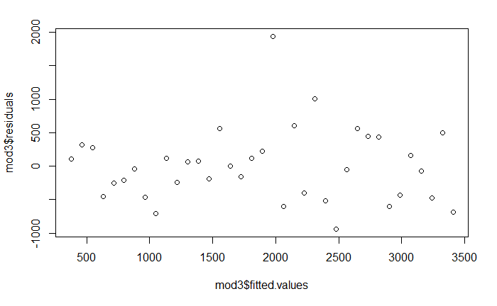

```r
plot(mod3$residuals ~ mod3$fitted.values)
```

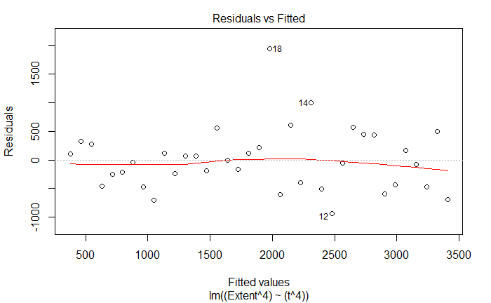

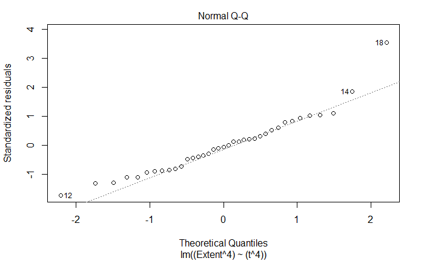

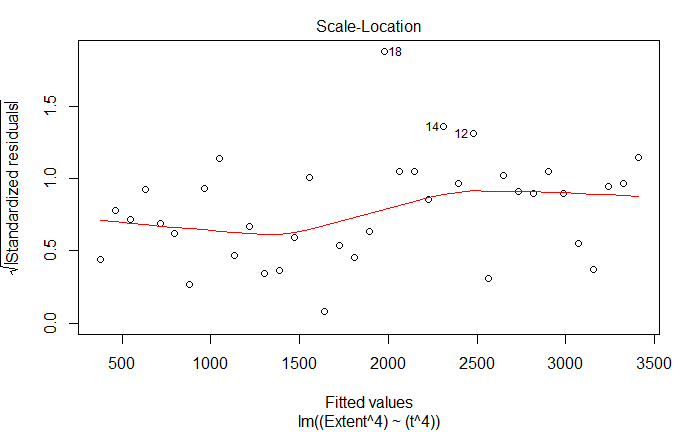

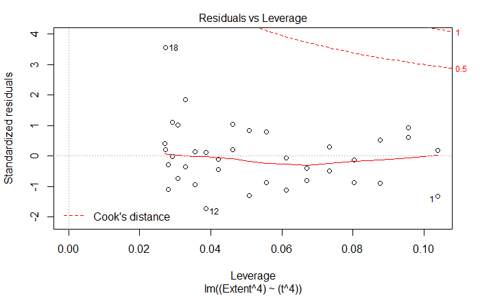

```r
plot(mod3)
```

```r
summary(mod3)
```

```
Call:
lm(formula = (Extent^4) ~ (t^4), data = SeaIce)

Residuals:
    Min      1Q  Median      3Q     Max
-935.76 -430.67  -38.31  273.52 1938.43

Coefficients:
            Estimate Std. Error t value Pr(>|t|)
(Intercept) 3491.106    185.984  18.771  < 2e-16 ***
t            -84.154      8.534  -9.862 1.22e-11 ***
---
Signif. codes:  0 ‘***’ 0.001 ‘**’ 0.01 ‘*’ 0.05 ‘.’ 0.1 ‘ ’ 1

Residual standard error: 554.2 on 35 degrees of freedom
Multiple R-squared:  0.7353,    Adjusted R-squared:  0.7278
F-statistic: 97.25 on 1 and 35 DF,  p-value: 1.22e-11
```

The p-values for the slope hypothesis test is at 1.22e-11, signifying the model is an appropriate linear model. ***